# Impulse Response Inference for Matrix Time Series

Midwest Econometrics Group

Ivan Ricardo

Maastricht University

Alain Hecq

Maastricht University

Ines Wilms

Maastricht University

October 10, 2026

## Data Structures

#### Univariate $(y_t)$

$$\begin{bmatrix}
\bullet \\
\bullet \\
\bullet
\end{bmatrix}$$

#### Multivariate $(\mathbf{y}_t)$

$$\begin{bmatrix}
\bullet & \bullet & \bullet \\
\bullet & \bullet & \bullet \\
\bullet & \bullet & \bullet
\end{bmatrix}$$

#### Matrix-valued $(\mathbf{Y}_t)$

[figure not shown]

Examples of matrix-valued data include

- Global VAR panels: countries $\times$ variables (Pesaran et al. 2004)
- Fama-French portfolios: size $\times$ book-to-market (Wang et al. 2019)
- State employment: states $\times$ industries (Samadi and Billard 2024)

## Our Setting

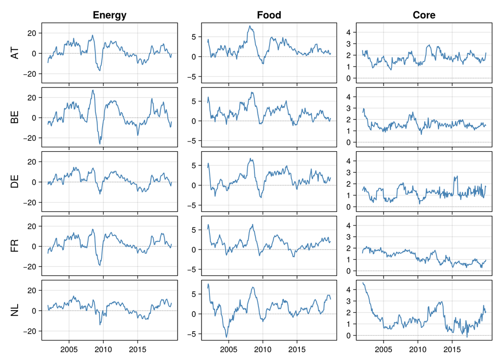

- Monthly year-on-year HICP inflation, December 2001 to December 2019
- How does an energy shock pass through into food and core inflation, and does it differ **across countries**?

## Why Matrix-valued data?

- Vectorizing loses **dimension-specific interpretations**, e.g., which country, which category
- Allows for more **parsimonious models**

|  | Coefficients ($N_1 = 5$, $N_2 = 3$, $p = 2$) |
| --- | --- |
| VAR($p$) on $\operatorname{vec}(\mathbf{Y}_t)$ | $(N_1 N_2)^2 p = 450$ |
| MAR($p$) | $(N_1^2 + N_2^2 - 1)p = 66$ |

**What is missing**

MAR impulse responses are reported as point estimates, or with residual bootstrap bands whose validity under the Kronecker restriction has not been established.

## Main Contributions

- **Asymptotic inference.** Joint asymptotic distribution of the MAR($p$) coefficient **and** covariance estimators, giving closed-form intervals
- **Bootstrap inference.** ProBAB-MAR, a bias-corrected bootstrap whose bootstrap samples are always generated by a MAR, with asymptotically correct coverage
- **Structure.** The rank of MAR impulse responses, and how proportional co-movement relaxes with the horizon

In simulations ProBAB intervals attain near-nominal coverage, with bands **much narrower** than the unrestricted VAR

# From VAR to MAR

## Matrix Autoregressive Model (MAR)

The MAR($p$) of Chen et al. (2021)
$$\mathbf{Y}_t = \sum_{j=1}^{p} \mathbf{A}_j \mathbf{Y}_{t-j}\mathbf{B}_j^\top + \mathbf{U}_t,
\qquad \operatorname{Cov}(\operatorname{vec}(\mathbf{U}_t)) = \boldsymbol{\Sigma}_2 \otimes \boldsymbol{\Sigma}_1$$

Vectorizing gives a **restricted VAR**: $\mathbf{y}_t = \sum_{j=1}^{p} \underbrace{(\mathbf{B}_j \otimes \mathbf{A}_j)}_{\mathbf{C}_j}\mathbf{y}_{t-j} + \mathbf{u}_t$

**A1 (Stability).** All companion eigenvalues lie strictly inside the unit circle.

**A2 (Innovations).** $\mathbf{U}_t$ is white noise with covariance $\boldsymbol{\Sigma}_2 \otimes \boldsymbol{\Sigma}_1$, and $\boldsymbol{\Sigma}_1, \boldsymbol{\Sigma}_2 \succ 0$.

## Impulse Responses

Under A1–A2, $\mathbf{y}_t$ has the moving average representation
$$\mathbf{y}_{t} = \sum_{h=0}^{\infty} \boldsymbol{\Theta}_h \mathbf{u}_{t-h},
\qquad
\boldsymbol{\Theta}_0 = \mathbf{I}_{N_1 N_2}, \quad
\boldsymbol{\Theta}_h = \sum_{j=1}^{\min(p,h)} (\mathbf{B}_j \otimes \mathbf{A}_j)\, \boldsymbol{\Theta}_{h-j}$$

A shock to entry $(r,s)$ of $\mathbf{U}_t$ is $\mathbf{e}_k = \mathbf{e}_s \otimes \mathbf{e}_r$, and its response at each horizon is again a **matrix**,
$$\operatorname{unvec}(\boldsymbol{\Theta}_h \mathbf{e}_k) \in \mathbb{R}^{N_1 \times N_2} \quad \text{(countries} \times \text{categories)}$$

Structural shocks: $\theta_{ik,h} = \mathbf{e}_i^\top \boldsymbol{\Theta}_h \mathbf{P}\,\mathbf{e}_k$, with a separable impact matrix $\mathbf{P} = \mathbf{P}_2 \otimes \mathbf{P}_1$ from $\boldsymbol{\Sigma}_1 = \mathbf{P}_1\mathbf{P}_1^\top$ and $\boldsymbol{\Sigma}_2 = \mathbf{P}_2\mathbf{P}_2^\top$

## The Response Inherits the Structure

For a MAR($1$), $\boldsymbol{\Theta}_h = \mathbf{B}_1^h \otimes \mathbf{A}_1^h$, so a shock to entry $(r,s)$ gives
$$\operatorname{unvec}(\boldsymbol{\Theta}_h \mathbf{e}_k)
= \underbrace{(\mathbf{A}_1^h\mathbf{e}_r)}_{\text{row response}}
\;\underbrace{(\mathbf{B}_1^h\mathbf{e}_s)^\top}_{\text{column response}}$$

A **rank-one** matrix where every country responds with the same pattern across categories, scaled by a country-specific factor (Chen et al. 2021).

**Proposition 1: MAR($p$)**

Under A1, for a Kronecker shock $\mathbf{v} = \mathbf{v}_2 \otimes \mathbf{v}_1$ (e.g. $\mathbf{e}_k$), $\operatorname{rank}\big(\operatorname{unvec}(\boldsymbol{\Theta}_h \mathbf{v})\big) \le \min\{c_h, N_1, N_2\}$, where $c_0 = 1$ and $c_h = \sum_{j=1}^{\min(p,h)} c_{h-j}$.

Proportional co-movement is relaxed **gradually** with the horizon.

# Inference for MAR Impulse Responses

## Joint Asymptotic Normality

**A3 (i.i.d. innovations).** A2 holds, the $\mathbf{U}_t$ are i.i.d., and $\mathbb{E}\|\mathbf{U}_t\|_F^4 < \infty$.

**Proposition 2**

Let A1 and A3 hold, and let $\widehat{\boldsymbol{\zeta}}$ be the Gaussian QMLE of $\boldsymbol{\zeta} = (\boldsymbol{\beta}^\top, \boldsymbol{\sigma}^\top)^\top$, with coefficients $\boldsymbol{\beta}$ and covariance parameters $\boldsymbol{\sigma}$. Then
$$\sqrt{T}(\widehat{\boldsymbol{\zeta}} - \boldsymbol{\zeta}) \xrightarrow{d} N(\mathbf{0}, \boldsymbol{\Omega}),
\qquad \boldsymbol{\Omega} = \operatorname{blkdiag}(\boldsymbol{\Omega}_\beta, \boldsymbol{\Omega}_\sigma)$$

- The coefficient block is known (Chen et al. 2021), we provide the covariance block and the joint law
- The covariance block depends on fourth moments of $\mathbf{U}_t$

## From Parameters to Responses

An identified response depends on **both** blocks:
$$\theta_{ik,h} = g_{ik,h}(\boldsymbol{\zeta}) = \mathbf{e}_i^\top \boldsymbol{\Theta}_h(\boldsymbol{\beta})\,\mathbf{P}(\boldsymbol{\sigma})\,\mathbf{e}_k$$

**A4 (Non-degeneracy).** $\nabla g_{ik,h}(\boldsymbol{\zeta}) \neq \mathbf{0}$, so the limiting variance of $\widehat{\theta}_{ik,h}$ is positive.

Under A1, A3 and A4, the delta method gives closed-form intervals with correct asymptotic coverage at any fixed $h$.

Closed form, but centered at a **biased** estimate in small samples.

## Where the BAB-MAR Stops Working

Bootstrap-after-bootstrap (Kilian 1998): bootstrap to estimate the bias, correct the **coefficients**, then bootstrap again from the corrected model.

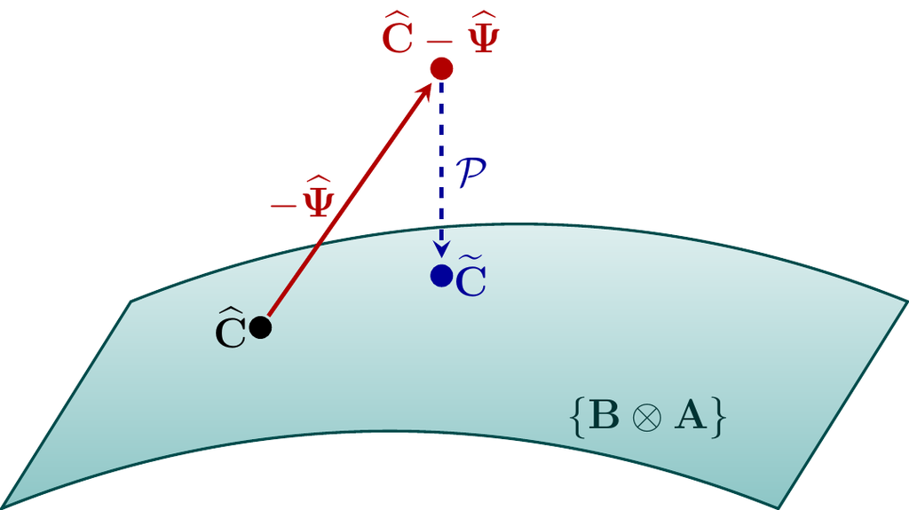

- $\widehat{\mathbf{C}}_j = \widehat{\mathbf{B}}_j \otimes \widehat{\mathbf{A}}_j$ lies on the set of Kronecker products
- The bias estimate $\widehat{\boldsymbol{\Psi}}_j$ need not have this form
- So $\widehat{\mathbf{C}}_j - \widehat{\boldsymbol{\Psi}}_j$ is **not** a Kronecker product

**Bootstrap design and estimator disagree**

Samples are drawn from a process that is **not a MAR**, while every replication is re-estimated **as one**.

## Projecting Back

Nearest Kronecker product (Van Loan and Pitsianis 1993)
$$\mathcal{P}(\mathbf{C}_j) = \underset{\mathbf{V}\otimes\mathbf{U}}{\arg\min}\;\|\mathbf{C}_j - \mathbf{V}\otimes\mathbf{U}\|_F^2$$

A rearrangement defined by $\mathcal{R}(\cdot)$ turns this into
$$\|\mathbf{C}_j - \mathbf{V}\otimes\mathbf{U}\|_F^2 = \|\mathcal{R}(\mathbf{C}_j) - \operatorname{vec}(\mathbf{U})\operatorname{vec}(\mathbf{V})^\top\|_F^2,$$
a **rank-one approximation** found via SVD.

**Order matters**

The projection says nothing about eigenvalues and can push a root outside the unit circle. Project **first**, then check stability.

## ProBAB-MAR

- **Stage 1.** Bootstrap from $\widehat{\mathbf{C}}$, $B_1$ times. Estimate $\widehat{\boldsymbol{\Psi}} = \bar{\mathbf{C}}^* - \widehat{\mathbf{C}}$ and set
  $$\widetilde{\mathbf{C}}_j = \mathcal{P}\big(\widehat{\mathbf{C}}_j - \delta\widehat{\boldsymbol{\Psi}}_j\big) = \widetilde{\mathbf{B}}_j \otimes \widetilde{\mathbf{A}}_j$$
- **Stage 2.** Bootstrap from $\widetilde{\mathbf{C}}$, $B_2$ times. Re-fit, correct and project again, $\widetilde{\mathbf{C}}^* = \mathcal{P}(\widehat{\mathbf{C}}^* - \delta^*\widehat{\boldsymbol{\Psi}})$, and compute the responses
- **Interval.** Percentile, from the $B_2$ draws

**Structure preserved throughout**

Every matrix that generates data, and every matrix estimated from it, factors as $\mathbf{B}_j \otimes \mathbf{A}_j$.

Full algorithm

## Asymptotic Validity

**Recall.** A1 stability, A2 separable white noise, A3 iid with fourth moments, A4 $\nabla g_{ik,h}(\boldsymbol{\zeta}) \neq \mathbf{0}$

**Proposition 3**

Let A1 and A3 hold. The plain residual bootstrap is consistent for the MAR: $\sqrt{T}(\widehat{\boldsymbol{\zeta}}^* - \widehat{\boldsymbol{\zeta}}) \xrightarrow{d^*} N(\mathbf{0}, \boldsymbol{\Omega})$ in probability.

Bias correction, projection and shrinkage each perturb the bootstrap DGP by $o_p(T^{-1/2})$, negligible against the $T^{-1/2}$ sampling error.

**Corollary**

Let A1–A4 hold and fix $h \ge 0$. Then the ProBAB-MAR percentile interval satisfies
$$\lim_{T\to\infty} P\Big(\theta_{ik,h}\in \big[\widetilde{\theta}_{ik,h}^{*(\alpha/2)},\,\widetilde{\theta}_{ik,h}^{*(1-\alpha/2)}\big]\Big) = 1-\alpha$$

Assumptions

# Simulation Study

## Calibrated to the Application

MAR(2) at the euro-area estimates, $T = 200$. Response of **Dutch food inflation** to a unit innovation in energy inflation in all five countries at once

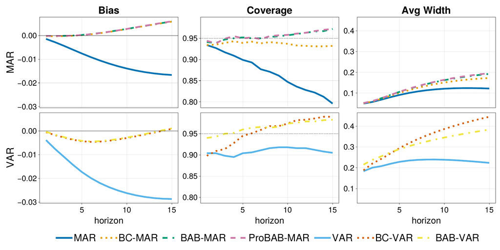

- Delta method falls to $80\%$; **ProBAB-MAR near nominal** at every horizon
- BAB-VAR also covers, but its bands are on average **$2.57\times$ as wide**

## Coverage in Small Samples

MAR(1), $N_1 = 3$, $N_2 = 4$, $\rho_{\max} = 0.8$, $T = 100$

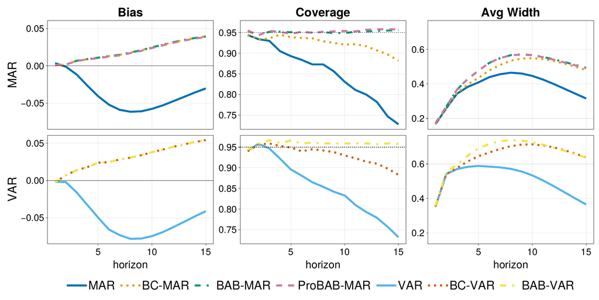

- Delta method falls to $74\%$; ProBAB at the nominal level at every horizon
- MAR bands about **two thirds** the width of BAB-VAR

Near the unit root

## A Common Energy Shock

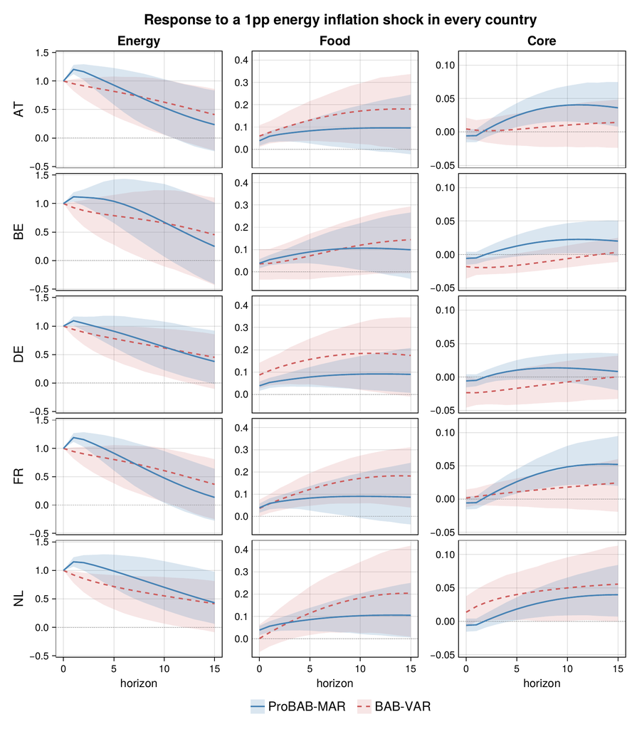

- **MAR(2)** and **VAR(1)**, each at the lag order chosen by BIC and Hannan-Quinn
- Energy ordered first; the shock raises energy inflation by **1 pp** on impact in all five countries
- An **energy innovation**, not an oil supply shock, so it mixes supply and demand

Same lag order

## What the Comparison Shows

- **Same story, tighter bands.** Point estimates track closely with ProBAB-MAR bands being about $1.4\times$ narrower ($1.6\times$ against a VAR(2))
- **The VAR can barely bias-correct.** Shrinkage binds in $99\%$ of VAR replications against $23\%$ for the MAR; on average $18\%$ of the correction is applied, against $92\%$
- **Heterogeneity from $h = 2$.** At $h = 1$ the response is rank one and differences across countries emerge only later, which a MAR(1) would rule out

Kronecker structure?

# Conclusion

## Conclusion

- Joint asymptotic distribution of the MAR($p$) coefficient and covariance estimators, with delta-method intervals for identified responses
- ProBAB-MAR keeps the bias correction inside the Kronecker structure and attains asymptotically correct coverage, with bands narrower than the unrestricted VAR
- MAR($p$) responses relax proportional co-movement with the horizon

### Link to Paper

[figure not shown]

### Github

[figure not shown]

## References

Chen, Rong, Han Xiao, and Dan Yang. 2021. “Autoregressive Models for Matrix-Valued Time Series.” *Journal of Econometrics*, Annals Issue: Financial Econometrics in the Age of the Digital Economy, vol. 222 (1, Part B): 539–60.

Guggenberger, Patrik, Frank Kleibergen, and Sophocles Mavroeidis. 2023. “A Test for Kronecker Product Structure Covariance Matrix.” *Journal of Econometrics* 233 (1): 88–112.

Inoue, Atsushi, and Lutz Kilian. 2020. “The Uniform Validity of Impulse Response Inference in Autoregressions.” *Journal of Econometrics* 215 (2): 450–72.

Kilian, Lutz. 1998. “Small-Sample Confidence Intervals for Impulse Response Functions.” *Review of Economics and Statistics* 80 (2): 218–30.

Kleibergen, Frank, and Richard Paap. 2006. “Generalized Reduced Rank Tests Using the Singular Value Decomposition.” *Journal of Econometrics* 133 (1): 97–126.

Montiel Olea, José Luis, Mikkel Plagborg-Møller, Eric Qian, and Christian K. Wolf. 2026. “Local Projections or Vector Autoregressions? A Primer for Macroeconomists.” *NBER Macroeconomics Annual* 40: 111–52.

Pesaran, M. Hashem, Til Schuermann, and Scott M. Weiner. 2004. “Modeling Regional Interdependencies Using a Global Error-Correcting Macroeconometric Model.” *Journal of Business & Economic Statistics* 22 (2): 129–62.

Samadi, S. Yaser, and Lynne Billard. 2024. “On a Matrix-Valued Autoregressive Model.” *Journal of Time Series Analysis*.

Srivastava, Muni S, Tatjana von Rosen, and Dietrich Von Rosen. 2008. “Models with a Kronecker Product Covariance Structure: Estimation and Testing.” *Mathematical Methods of Statistics* 17 (4): 357–70.

Sung, Bongjung, and Peter D Hoff. 2025. “Testing Separability of High-Dimensional Covariance Matrices.” *arXiv Preprint arXiv:2506.17463*.

Van Loan, Charles F, and Nikos Pitsianis. 1993. “Approximation with Kronecker Products.” In *Linear Algebra for Large Scale and Real-Time Applications*. Springer.

Wang, Dong, Xialu Liu, and Rong Chen. 2019. “Factor Models for Matrix-Valued High-Dimensional Time Series.” *Journal of Econometrics* 208 (1): 231–48.

# Appendix

## Is the Kronecker Structure Right?

- Imposing a false Kronecker structure can bias responses and distort coverage (Montiel Olea et al. 2026)
- In our data, Schwarz and Hannan–Quinn prefer the MAR to the VAR on a common sample of $205$ months
- Covariance separability tests exist (Srivastava et al. 2008; Sung and Hoff 2025)
- For the coefficients, $\mathbf{C}_j$ is a Kronecker product iff its rearrangement $\mathcal{R}(\mathbf{C}_j)$ has rank one, so a rank test applies (Kleibergen and Paap 2006; Guggenberger et al. 2023)

Back to main

## Near the Unit Root

MAR(1), $N_1 = 3$, $N_2 = 4$, $T = 100$, largest root $\rho_{\max} = 0.99$

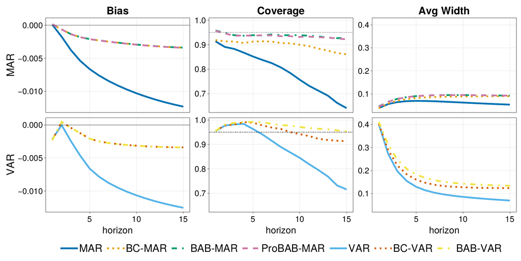

Back to main

## Same Lag Order in the Application

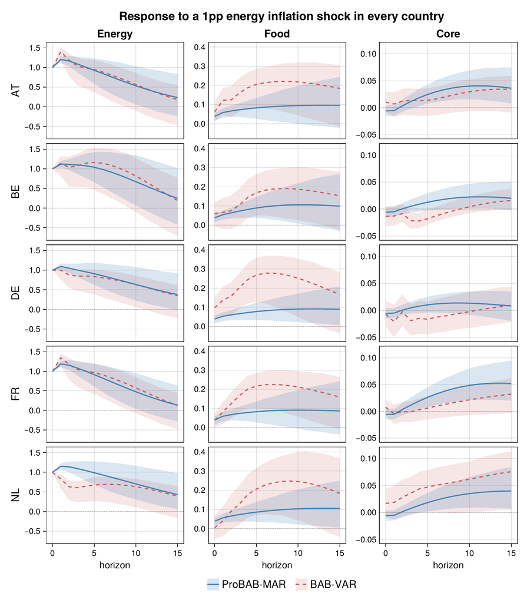

- VAR(2) on the vectorized system: $450$ coefficients against $66$ for the MAR(2)
- ProBAB-MAR bands narrower by $1.6\times$ in mean and $1.4\times$ in median
- Against $1.4\times$ and $1.3\times$ for the VAR(1)

Back to main

## Assumptions

- **A1 (Stability).** All companion eigenvalues strictly inside the unit circle; for $p = 1$, $\rho(\mathbf{A}_1)\rho(\mathbf{B}_1) < 1$
- **A2 (Innovations).** White noise, $\operatorname{Cov}(\operatorname{vec}(\mathbf{U}_t)) = \boldsymbol{\Sigma}_2 \otimes \boldsymbol{\Sigma}_1$, with $\boldsymbol{\Sigma}_1, \boldsymbol{\Sigma}_2 \succ 0$
- **A3 (i.i.d. innovations).** A2, plus i.i.d. with $\mathbb{E}\|\mathbf{U}_t\|_F^4 < \infty$
- **A4 (Non-degeneracy).** $\nabla g_{ik,h}(\boldsymbol{\zeta}) \neq \mathbf{0}$
- Proposition 1 uses A1; Propositions 2 and 3 use A1 and A3; the coverage results add A4
- Gaussianity is not required: the estimator is quasi-ML
- A4 excludes the reduced-form response at $h = 0$, since $\boldsymbol{\Theta}_0 = \mathbf{I}$ is known, and entries a Cholesky scheme sets to zero
- The guarantee is **pointwise** in the parameter, not uniform up to the unit circle

Back to main

## ProBAB-MAR Algorithm

1. Fit the MAR: $\widehat{\mathbf{C}}_j = \widehat{\mathbf{B}}_j \otimes \widehat{\mathbf{A}}_j$ and residuals $\widehat{\mathbf{u}}_t$
2. **Stage 1.** For $m = 1, \ldots, B_1$: resample residuals, simulate from $\widehat{\mathbf{C}}$ with zero initial values, re-fit to get $\widehat{\mathbf{C}}^{*(m)}$
3. Bias $\widehat{\boldsymbol{\Psi}} = \bar{\mathbf{C}}^* - \widehat{\mathbf{C}}$. Take the largest $\delta \in \{1, 0.99, \ldots, 0.01\}$ with $\rho\big(\mathcal{P}(\widehat{\mathbf{C}} - \delta\widehat{\boldsymbol{\Psi}})\big) < 1$ and set $\widetilde{\mathbf{C}} = \mathcal{P}(\widehat{\mathbf{C}} - \delta\widehat{\boldsymbol{\Psi}})$; no correction if none qualifies
4. **Stage 2.** For $m = 1, \ldots, B_2$: resample residuals, simulate from $\widetilde{\mathbf{C}}$, re-fit, compute $\delta^*$, set $\widetilde{\mathbf{C}}^* = \mathcal{P}(\widehat{\mathbf{C}}^* - \delta^*\widehat{\boldsymbol{\Psi}})$, re-estimate $\boldsymbol{\sigma}^*$ from its residuals, and compute $\widetilde{\theta}^{*(m)}_{ik,h} = \mathbf{e}_i^\top \widetilde{\boldsymbol{\Theta}}^*_h \mathbf{P}^* \mathbf{e}_k$
5. Percentile interval from $\{\widetilde{\theta}^{*(m)}_{ik,h}\}_{m=1}^{B_2}$

Reusing $\widehat{\boldsymbol{\Psi}}$ in Stage 2 needs $B_1 + B_2$ re-estimations instead of $B_1 B_2$.

Back to main